In this part we explain the backstory of the whole foods counties (popularized by David Wasserman) and answer interesting questions such as:

- What are the differences between whole foods counties and non-whole foods counties?
- Total % of TX population
- Demographic percentages
- Age group percentages

#### Whole Food Counties Backstory and Process

One way of understanding the vote in Texas is by using the counties that have Whole Foods stores located in them to essentially split the state up into urban and rural areas. This method was popularized by political analyst David Wasserman of the Cook Political Report. Since there were no exisiting data for which county in Texas has the Whole Foods store, we manually created the dataset based on the Whole Foods store locator *(found at https://www.wholefoodsmarket.com/stores)* combined with Google Maps.

The cities and counties that Whole Foods are located in Texas are as follows: El Paso (El Paso County), San Antonio (Bexar County), Austin (Travis and Williamson Counties), Houston (Montgomery, Harris, and Fort Bend Counties), Dallas Fort Worth (Dallas, COllin, Denton, and Tarrant Counties). This is a total of 11 counties. So of the 254 counties in the state of Texas, 243 of them are not “Whole Foods Counties.”

#### Early Vote in Whole Foods vs. Non-Whole Foods Counties

This is quite interesting, as this story line did not make its way into the pre-election coverage that we saw. In fact, last minute the momentum was swinging in the democrats direction, while the early vote in this instance tells a different story.

#### Comparing the Racial Demographics of Whole Foods vs. Non-Whole Foods Counties

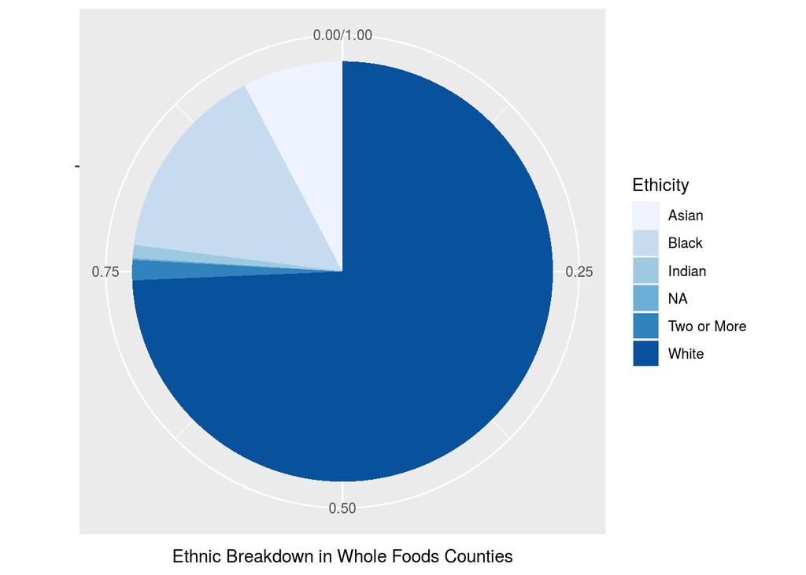

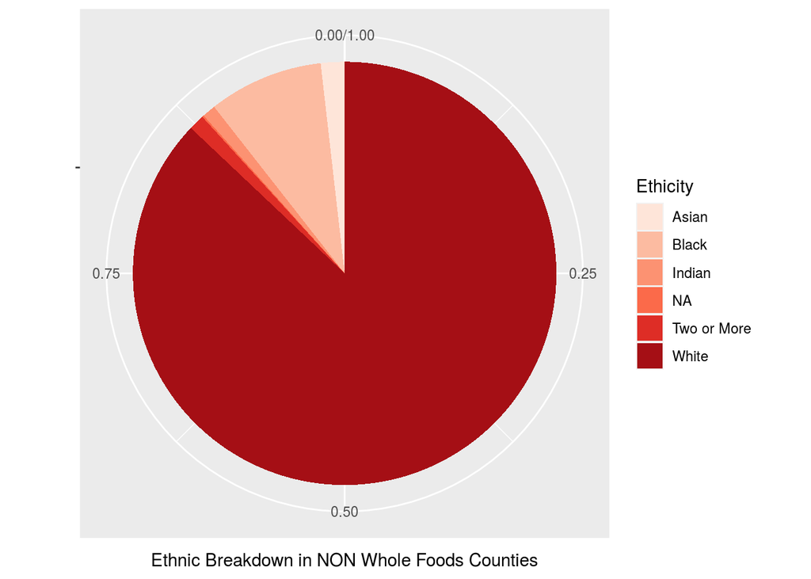

[figure not shown]

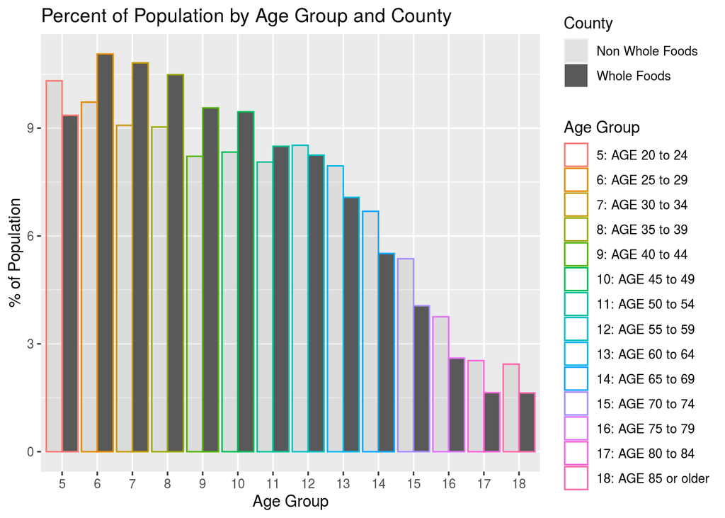

When comparing the two age plots side by side, it is clear that there are differences in the distribution of the ages between the two groups of counties. When looking at the non-Whole Foods counties, the only time a group reaches 10% of the voting age population is for group 5. However, when looking at the Whole Foods counties, group 5 is below 10%, while groups 6 through 8 are over 10%. This suggests that the Whole Foods generally have a higher percentage of young people than the non Whole Foods counties.

#### New Part: What was correlated with Election Day Turnout

```
## # A tibble: 253 x 2
##    COUNTY      election_day_votes
##    <chr>                    <int>
##  1 ""                       13264
##  2 "ANDERSON"                4694
##  3 "ANDREWS"                 1079
##  4 "ANGELINA"                5963
##  5 "ARANSAS"                 1266
##  6 "ARCHER"                  1176
##  7 "ARMSTRONG"                266
##  8 "ATASCOSA"                3294
##  9 "AUSTIN"                  3026
## 10 "BAILEY"                   575
## # … with 243 more rows
```